# Time Series Anlaysis. Practice 3. ARIMA Models

Miguel Albertí Pons, Iker González Cuellar, Pol Martínez Collado

01-02-23

```r
library(dplyr)
library(tidyr)
library(reshape2)
library(magrittr)
library(stringr)
library(astsa)
library(forecast)
library(ggplot2)
```

# **Exercise 1**

**Read the IPC data as you did in the last homework. Then compute the Inflation as Inflation <- 100*diff(IPC,lag=12)/lag(IPC,k=-12) and the regularly and seasonally differentiated IPC time series as IPC.d1.d12 <- diff( diff(IPC,lag=12), lag=1).**

```r
ipcDataRaw = read.csv("_repository/INE_IPC.csv", sep = ",")

# IPC INDEX
# ----------------------------------
table_range = 1:196
ipcIndex = ipcDataRaw[c(6,7),table_range]
names(ipcIndex) = ipcIndex[1,]
ipcIndex = ipcIndex[-1,] %>% rename(., id = 1) %>% melt(., id = "id") %>% rename(., date = 2, index = 3) %>% .[,2:3] %>% arrange(., desc(date)) %>% transform(., index = as.double(index), date = as.Date(date))
ipcIndex.ts = ts(ipcIndex[2], frequency = 12, start=c(2002,01))

# Inflation
# ----------------------------------
divisor = lag(ipcIndex[,2],k=-12)
dividendo = 100*diff(ipcIndex[,2],lag=12)
Inflation = suppressWarnings(ts(dividendo/divisor, frequency = 12, start=c(2002,01)))
Inflation = na.omit(Inflation)


# seasonally differentiated IPC TS
# ----------------------------------
IPC.d1.d12 = diff(diff(ipcIndex.ts,lag=12), lag=1)
```

# **Exercise 2**

**Joint the two previous time series with ts.union and plot the resulting bivariate series.**

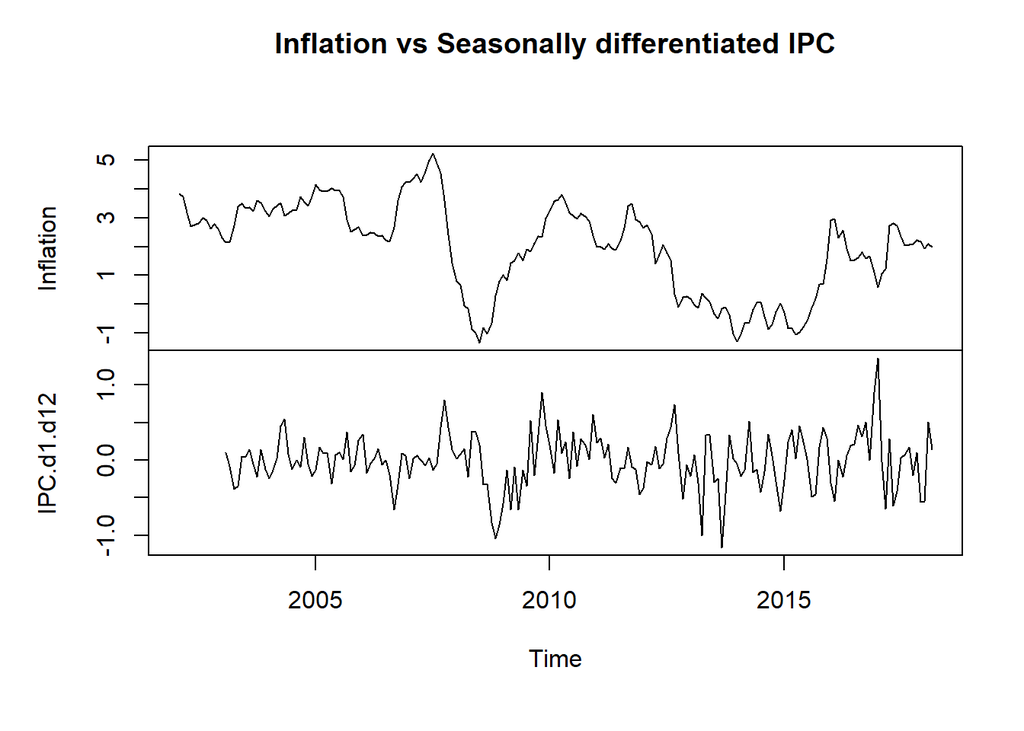

```r
inf.union.d1.d12 = ts.union(Inflation, IPC.d1.d12)

plot(inf.union.d1.d12, main="Inflation vs Seasonally differentiated IPC")
```

# **Exercise 3**

**Define Infl.d1 as the regular difference of Inflation. Check that this series is very similar to IPC.d1.d12.**

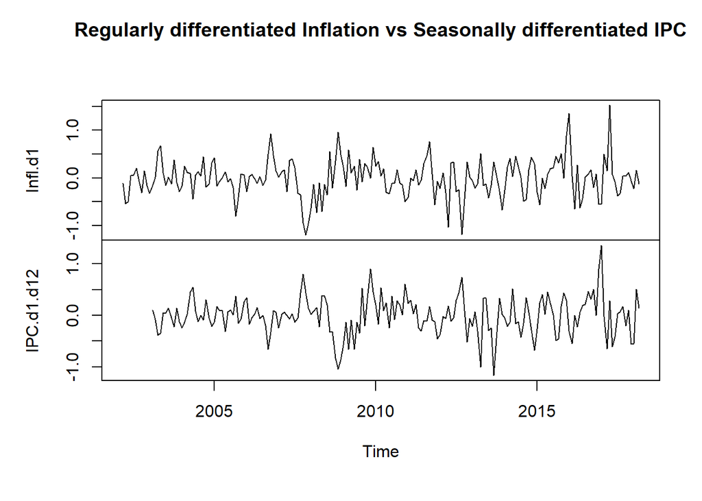

```r
Infl.d1 = diff(Inflation, lag = 1)

inf.d1.union.d1.d12 = ts.union(Infl.d1, IPC.d1.d12)

plot(inf.d1.union.d1.d12, main="Regularly differentiated Inflation vs Seasonally differentiated IPC")
```

Las series son muy parecidas. Es curioso el lag que presenta la serie IPC.d1.d12 respecto a Infl.d1 ya que parece que sigue la misma tendencia solo que desplazada hacia la derecha en el eje temporal.

# **Exercise 4**

**Using the function window, cut the time series IPC in two parts: a training part until December 2016, and a test part from January 2017. Call them IPC.tr and IPC.te, respectively. Then compute the** **regular and seasonal difference of IPC.tr and call the resulting series IPC.tr.d1.d12. Plot this series,** **as well as its ACF and its PACF.**

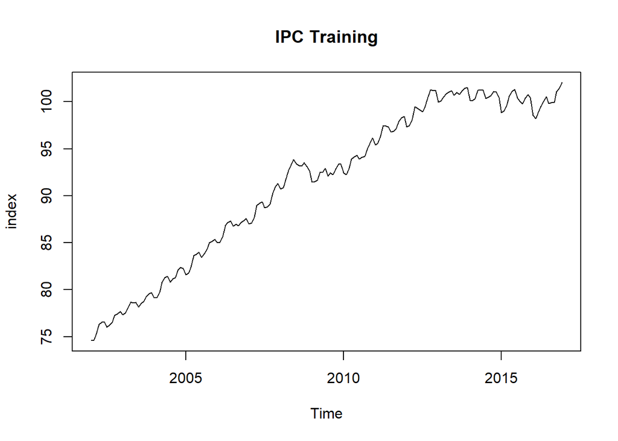

```r
end.tr = c(2016,12)
IPC.tr = window(ipcIndex.ts, end = end.tr)

start.te = c(2017,1)
IPC.te = window(ipcIndex.ts, start = start.te)

plot(IPC.tr, main="IPC Training")
```

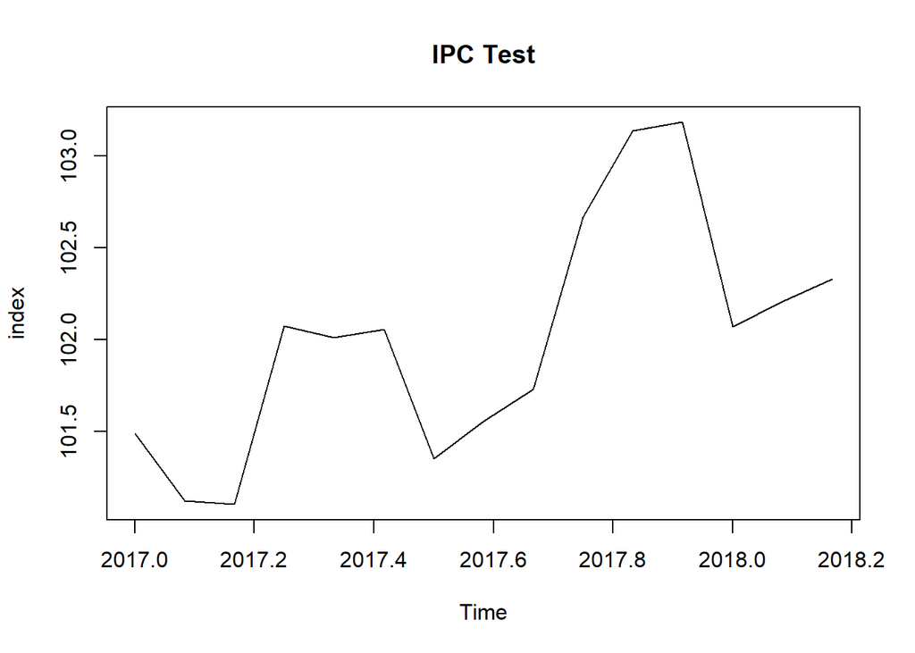

```r
plot(IPC.te, main="IPC Test")
```

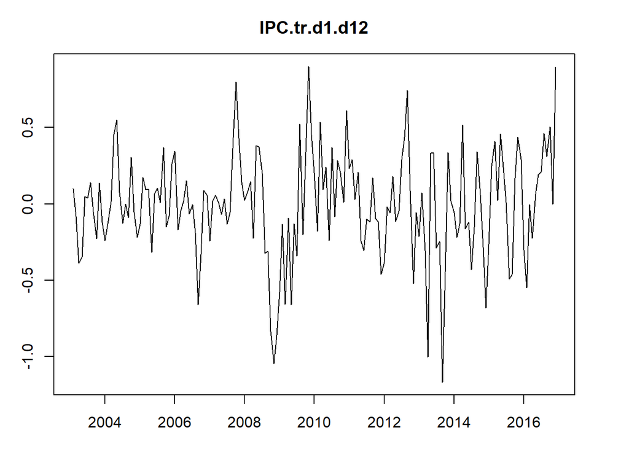

```r
IPC.tr.d1.d12 = diff(diff(IPC.tr,lag=1), lag=12)

par(mfrow = c(1,1), mar = c(rep(3,4)))
plot(IPC.tr.d1.d12, main = 'IPC.tr.d1.d12')
```

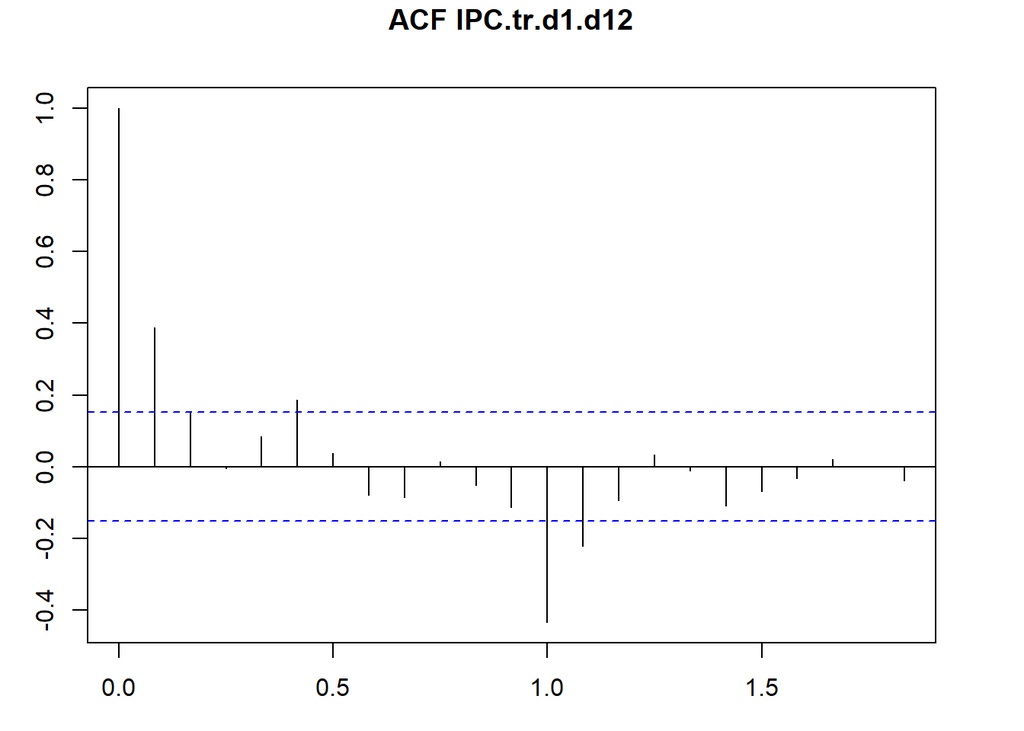

```r
acf(IPC.tr.d1.d12, main = 'ACF IPC.tr.d1.d12')
```

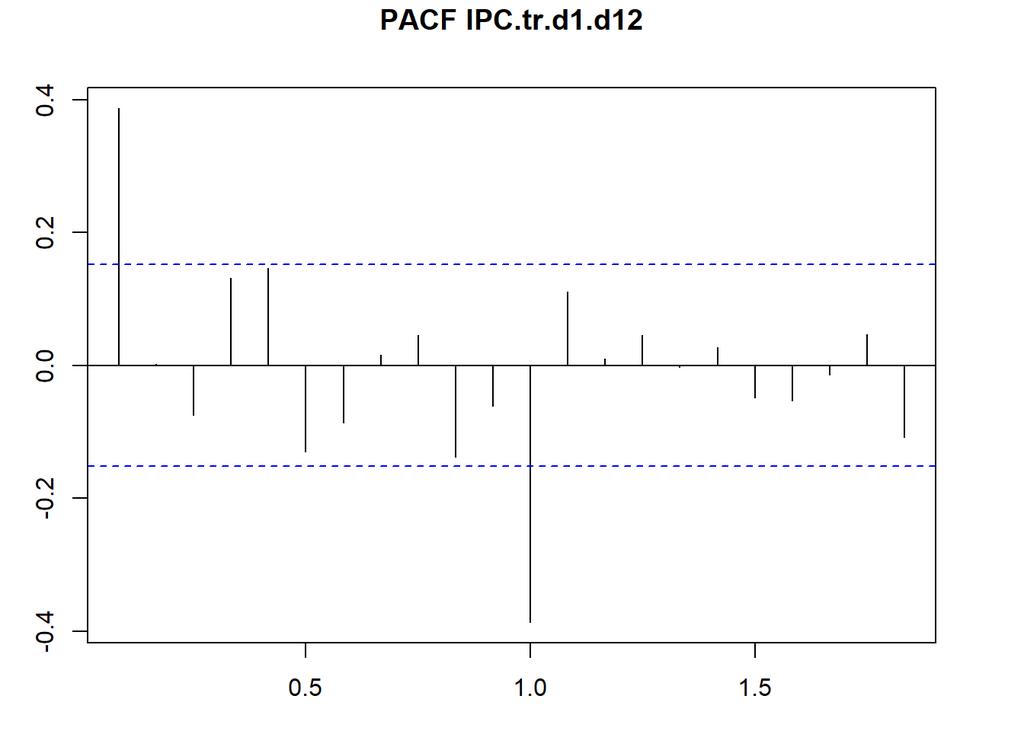

```r
pacf(IPC.tr.d1.d12, main = 'PACF IPC.tr.d1.d12')
```

# **Exercise 5**

**Based on the ACF and the PACF, propose at least two different ARMA models for IPC.tr.d1.d12.**

**a. Estimate the ARMA models you propose. Plot the residuals of them and the residuals ACF and PACF.**

Propuesta 1: ARMA(1,1) ya que tanto el ACF decrese rápidamente en el lag 1 y PACF decrese rápidamente después del lag 0.

Propuesta 2: ARMA(0,1) ya que el ACF a después del retardo 1 se aproxima a cero y se podria considerar un MA(1)

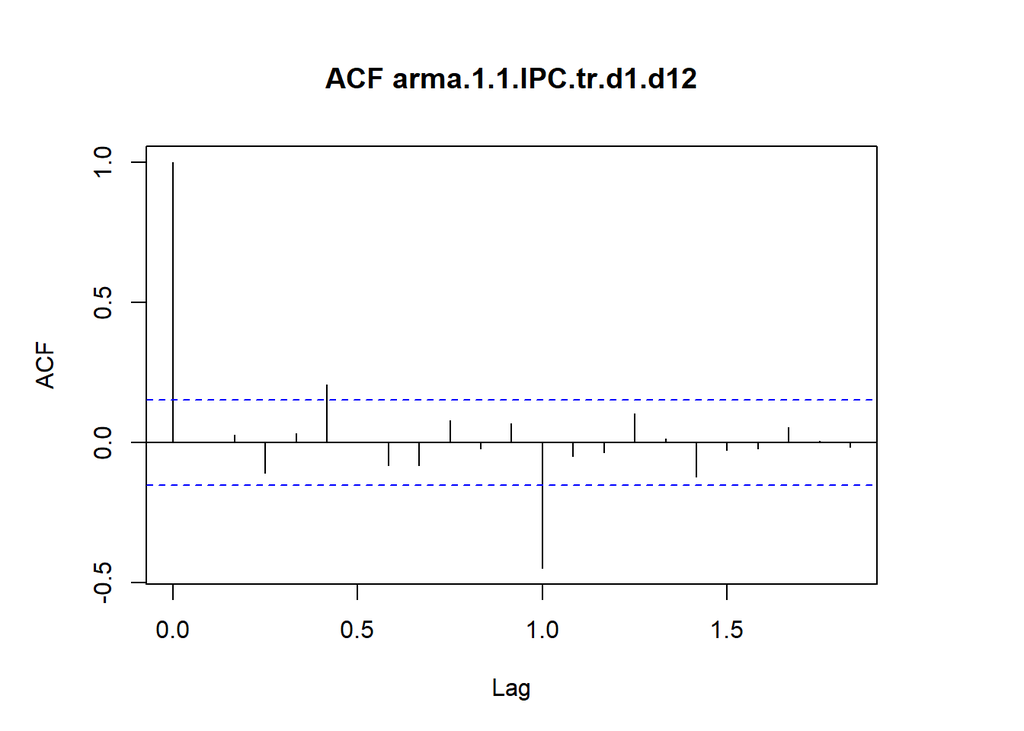

```r
#a.
#ARMA(1,1) propuesta model 1
arma.1.1.IPC.tr.d1.d12 = Arima(IPC.tr.d1.d12, order = c(1, 0, 1))

par(mfrow = c(1,1), mar = c(rep(5,4)))
acf(arma.1.1.IPC.tr.d1.d12$residuals, main = 'ACF arma.1.1.IPC.tr.d1.d12')
```

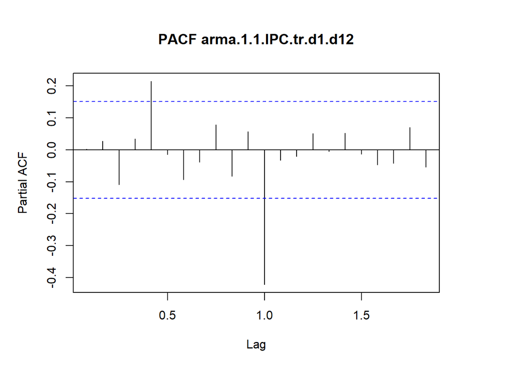

```r
pacf(arma.1.1.IPC.tr.d1.d12$residuals, main = 'PACF arma.1.1.IPC.tr.d1.d12')
```

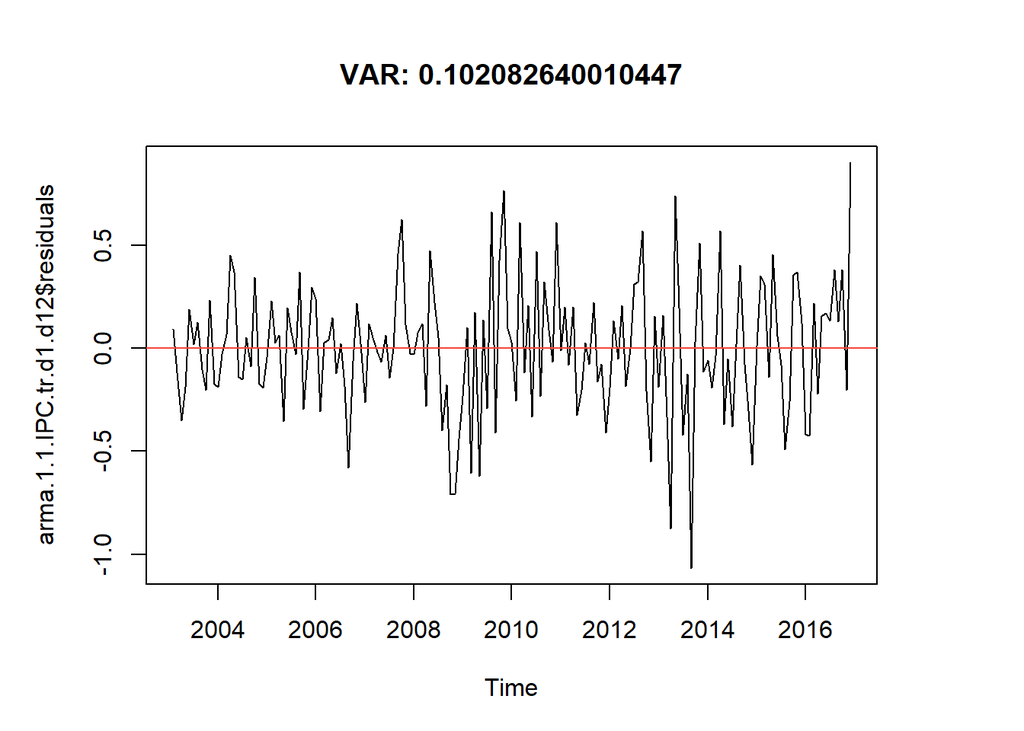

```r
Var = var(arma.1.1.IPC.tr.d1.d12$residuals)
plot(arma.1.1.IPC.tr.d1.d12$residuals, main = paste("VAR:",Var));abline(h=0, col=2)
```

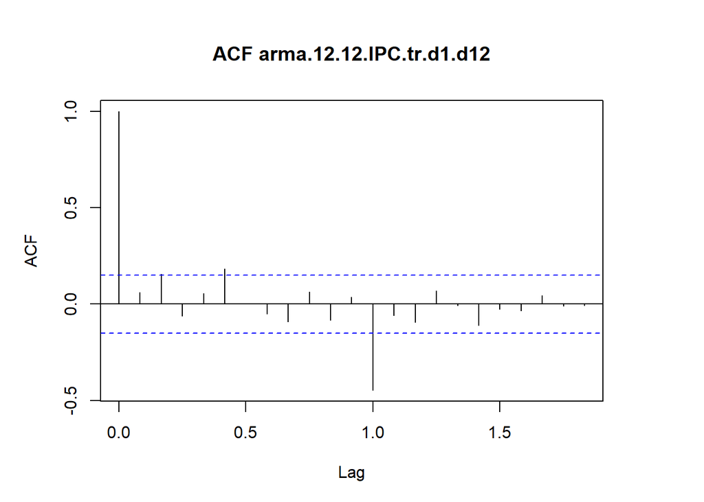

```r
#ARMA(0,1) propuesta model 2
arma.12.12.IPC.tr.d1.d12 = Arima(IPC.tr.d1.d12, order = c(0, 0, 1))

par(mfrow = c(1,1), mar = c(rep(5,4)))
acf(arma.12.12.IPC.tr.d1.d12$residuals, main = 'ACF arma.12.12.IPC.tr.d1.d12')
```

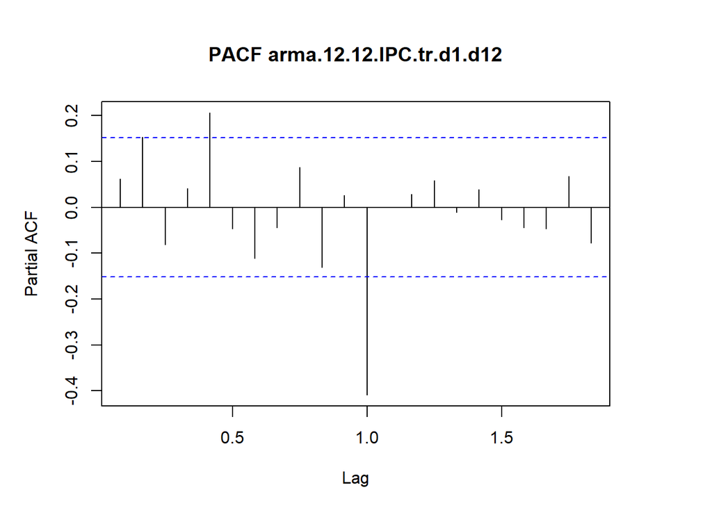

```r
pacf(arma.12.12.IPC.tr.d1.d12$residuals, main = 'PACF arma.12.12.IPC.tr.d1.d12')
```

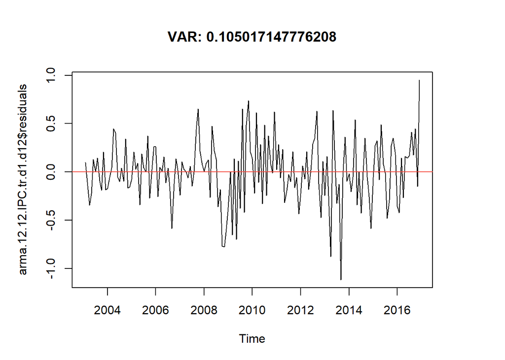

```r
Var = var(arma.12.12.IPC.tr.d1.d12$residuals)
plot(arma.12.12.IPC.tr.d1.d12$residuals, main = paste("VAR:",Var));abline(h=0, col=2)
```

**b. Which is the model suggested by auto.arima? Plot the residuals of this model and the residuals ACF and PACF.**

El modelo sugerido por auto.arima es:

*ARIMA(1,0,0)(0,0,1)[12]*

```r
#b.
#auto ARMA
auto.arma.IPC.tr.d1.d12 = auto.arima(IPC.tr.d1.d12, trace=TRUE)
```

```
##
##  Fitting models using approximations to speed things up...
##
##  ARIMA(2,0,2)(1,0,1)[12] with non-zero mean : 52.30675
##  ARIMA(0,0,0)            with non-zero mean : 124.3157
##  ARIMA(1,0,0)(1,0,0)[12] with non-zero mean : 66.03124
##  ARIMA(0,0,1)(0,0,1)[12] with non-zero mean : 35.16149
##  ARIMA(0,0,0)            with zero mean     : 122.3375
##  ARIMA(0,0,1)            with non-zero mean : 102.7251
##  ARIMA(0,0,1)(1,0,1)[12] with non-zero mean : 48.42586
##  ARIMA(0,0,1)(0,0,2)[12] with non-zero mean : 37.068
##  ARIMA(0,0,1)(1,0,0)[12] with non-zero mean : 70.21323
##  ARIMA(0,0,1)(1,0,2)[12] with non-zero mean : Inf
##  ARIMA(0,0,0)(0,0,1)[12] with non-zero mean : 57.17214
##  ARIMA(1,0,1)(0,0,1)[12] with non-zero mean : 35.04065
##  ARIMA(1,0,1)            with non-zero mean : 100.9922
##  ARIMA(1,0,1)(1,0,1)[12] with non-zero mean : 48.89364
##  ARIMA(1,0,1)(0,0,2)[12] with non-zero mean : 37.05346
##  ARIMA(1,0,1)(1,0,0)[12] with non-zero mean : 68.14662
##  ARIMA(1,0,1)(1,0,2)[12] with non-zero mean : Inf
##  ARIMA(1,0,0)(0,0,1)[12] with non-zero mean : 33.28878
##  ARIMA(1,0,0)            with non-zero mean : 98.89947
##  ARIMA(1,0,0)(1,0,1)[12] with non-zero mean : 47.29392
##  ARIMA(1,0,0)(0,0,2)[12] with non-zero mean : 35.31382
##  ARIMA(1,0,0)(1,0,2)[12] with non-zero mean : Inf
##  ARIMA(2,0,0)(0,0,1)[12] with non-zero mean : 36.16522
##  ARIMA(2,0,1)(0,0,1)[12] with non-zero mean : 38.30186
##  ARIMA(1,0,0)(0,0,1)[12] with zero mean     : 32.66101
##  ARIMA(1,0,0)            with zero mean     : 96.83729
##  ARIMA(1,0,0)(1,0,1)[12] with zero mean     : 45.69944
##  ARIMA(1,0,0)(0,0,2)[12] with zero mean     : 34.64518
##  ARIMA(1,0,0)(1,0,0)[12] with zero mean     : 63.9425
##  ARIMA(1,0,0)(1,0,2)[12] with zero mean     : 44.04073
##  ARIMA(0,0,0)(0,0,1)[12] with zero mean     : 59.23595
##  ARIMA(2,0,0)(0,0,1)[12] with zero mean     : 35.52157
##  ARIMA(1,0,1)(0,0,1)[12] with zero mean     : 34.52825
##  ARIMA(0,0,1)(0,0,1)[12] with zero mean     : 35.16569
##  ARIMA(2,0,1)(0,0,1)[12] with zero mean     : 37.62838
##
##  Now re-fitting the best model(s) without approximations...
##
##  ARIMA(1,0,0)(0,0,1)[12] with zero mean     : 37.27987
##
##  Best model: ARIMA(1,0,0)(0,0,1)[12] with zero mean
```

```r
summary(auto.arma.IPC.tr.d1.d12)
```

```
## Series: IPC.tr.d1.d12
## ARIMA(1,0,0)(0,0,1)[12] with zero mean
##
## Coefficients:
##          ar1     sma1
##       0.4134  -0.7176
## s.e.  0.0719   0.0665
##
## sigma^2 = 0.06771:  log likelihood = -15.57
## AIC=37.13   AICc=37.28   BIC=46.49
##
## Training set error measures:
##                       ME      RMSE     MAE      MPE     MAPE      MASE
## Training set -0.01791762 0.2586493 0.20475 -43.8958 300.7442 0.4572287
##                    ACF1
## Training set 0.01068861
```

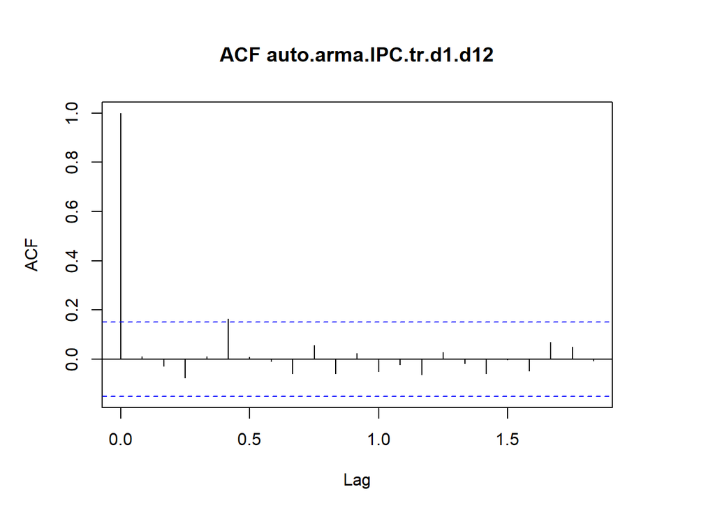

```r
par(mfrow = c(1,1), mar = c(rep(5,4)))
acf(auto.arma.IPC.tr.d1.d12$residuals, main = 'ACF auto.arma.IPC.tr.d1.d12')
```

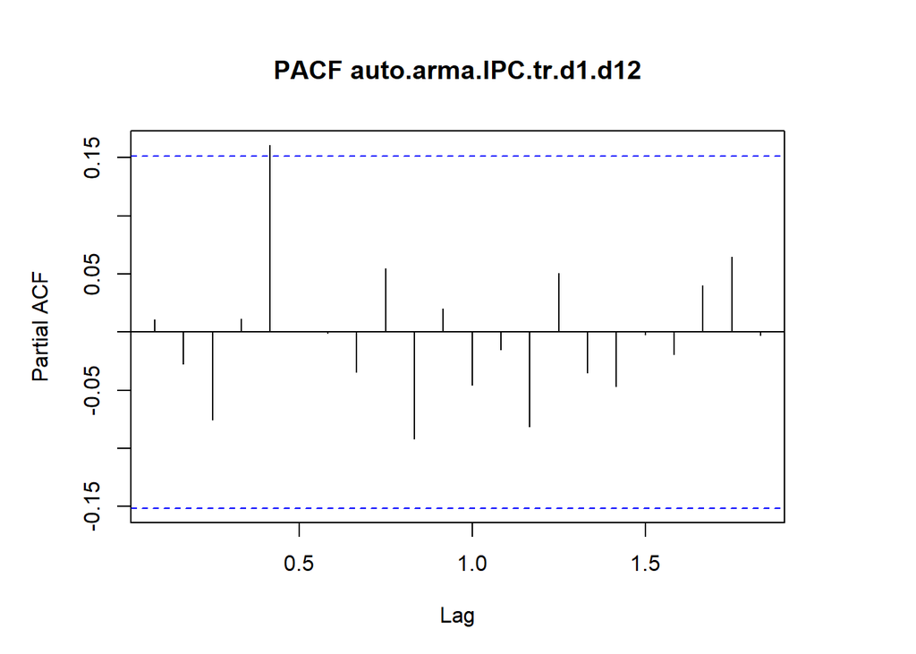

```r
pacf(auto.arma.IPC.tr.d1.d12$residuals, main = 'PACF auto.arma.IPC.tr.d1.d12')
```

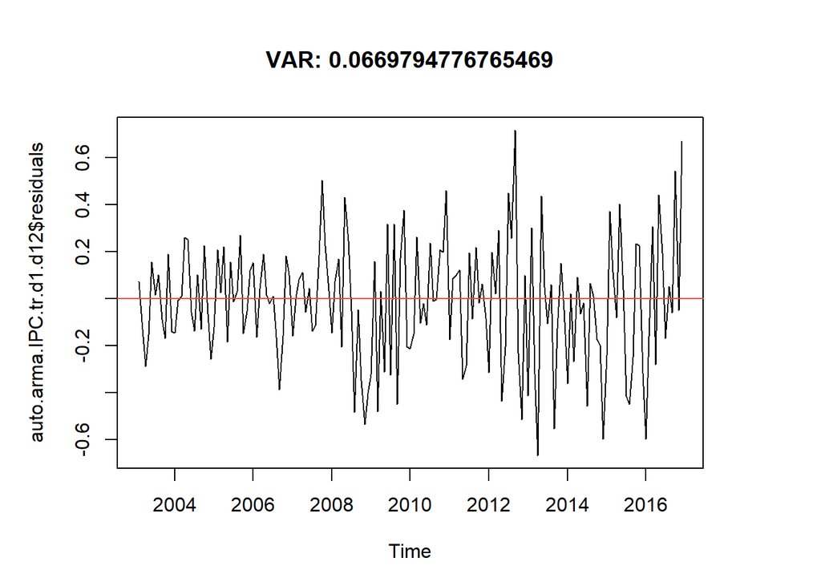

```r
Var = var(auto.arma.IPC.tr.d1.d12$residuals)
plot(auto.arma.IPC.tr.d1.d12$residuals, main = paste("VAR:",Var));abline(h=0, col=2)
```

**c. Which ARMA model do you chose finally for IPC.tr.d1.d12?.**

Escogeríamos el modelo proporcionado por aurto.arima (1,0,0)(0,0,1)[12], ya que su autocorrelación sigue una tendencia más orgánica y estacionaria que la de las dos propuestas ARMA y su varianza es notablemente menor (Var = 0.0669795).